# Ejercicio Guiado N°5 - Análisis de Datos y Estadística Computacional

- Mostrar todo el código
- Ocultar todo el código
- Ver el código fuente

Intervalos de Confianza con `infer`

Autor/a

Afiliación

Prof. Gabriel Duarte Zúñiga

Universidad Adolfo Ibáñez | DIAPP-2026

Fecha de publicación

23 de junio de 2026

**Antes de comenzar**

**Código**

```r
install.packages("tidyverse")
install.packages("infer")
```

**Código**

```r
library(tidyverse)
library(infer)
set.seed(2026)
```

# Ejercicio Guiado

Según el **Censo 2024**, en la región de **Arica y Parinacota** el **35,9%** de la población se identifica con un pueblo indígena u originario (87.816 de 244.569 personas). Para este ejercicio, simularemos esa población y tomaremos una muestra para construir un **intervalo de confianza** paso a paso con `infer`.

### Pregunta 1: Simular la población y tomar una muestra

Cree un tibble llamado `poblacion` con 244.569 filas y una variable `indigena` que tome los valores `"si"` o `"no"` con probabilidades 0.359 y 0.641 respectivamente (representando la proporción real del Censo). Luego, tome una muestra aleatoria de **200 personas** y guárdela en `muestra`. Calcule la proporción de `"si"` en la muestra. ¿Es exactamente 0.359?

**Pauta**

**Código**

```r
poblacion <- tibble(
  indigena = sample(c("si", "no"), size = 244569,
                    replace = TRUE, prob = c(0.359, 0.641))
)

muestra <- poblacion |> slice_sample(n = 200)

muestra |>
  count(indigena) |>
  mutate(prop = n / sum(n))
```

| indigena | n | prop |
| --- | --- | --- |
| no | 128 | 0.64 |
| si | 72 | 0.36 |

La proporción de la muestra ($\hat{p}$) no es exactamente 0.359: varía cada vez que tomamos una muestra distinta. Esa variabilidad es el **error muestral**, y es lo que vamos a cuantificar con el intervalo de confianza.

### Pregunta 2: Generar la distribución bootstrap

Usando `infer`, genere **1.000 remuestras bootstrap** a partir de `muestra` y calcule la proporción de `"si"` en cada una. Guarde el resultado en `dist_bootstrap` y visualícelo con `visualise()`.

**Pauta**

**Código**

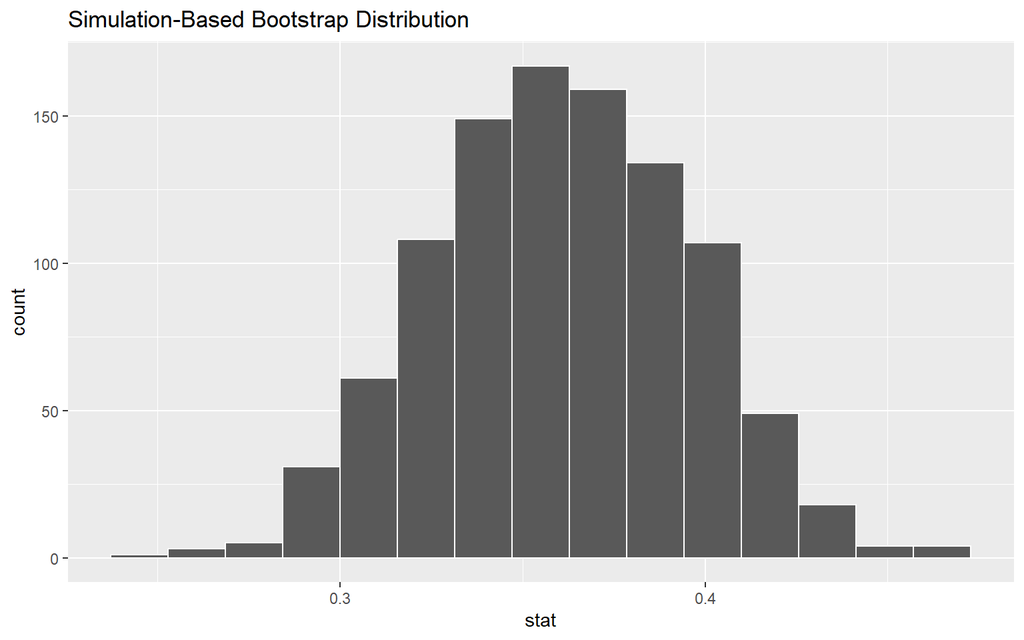

```r
dist_bootstrap <- muestra |>
  specify(response = indigena, success = "si") |>
  generate(reps = 1000, type = "bootstrap") |>
  calculate(stat = "prop")

dist_bootstrap |> visualise()
```

El histograma muestra cómo varía $\hat{p}$ entre remuestras. Está centrado aproximadamente en el valor de nuestra muestra y tiene forma acampanada.

### Pregunta 3: Construir el IC al 95%

A partir de `dist_bootstrap`, construya un intervalo de confianza al **95%** usando el método de **percentiles** y otro usando el método de **error estándar**. ¿Dan resultados similares?

**Pauta**

**Código**

```r
# Necesitamos el estimador puntual para el método de error estándar
p_hat <- muestra |>
  specify(response = indigena, success = "si") |>
  calculate(stat = "prop")

# Método de percentiles
ic_percentil <- dist_bootstrap |>
  get_confidence_interval(level = 0.95, type = "percentile")
ic_percentil
```

| lower_ci | upper_ci |
| --- | --- |
| 0.295 | 0.43 |

**Código**

```r
# Método de error estándar
ic_se <- dist_bootstrap |>
  get_confidence_interval(level = 0.95, type = "se", point_estimate = p_hat)
ic_se
```

| lower_ci | upper_ci |
| --- | --- |
| 0.2924102 | 0.4275898 |

Ambos métodos dan resultados muy similares. El de percentiles toma directamente los percentiles 2.5 y 97.5 de la distribución bootstrap. El de error estándar calcula $\hat{p} \pm 1.96 \times SE_{bootstrap}$. Con 1.000 remuestras, la diferencia entre ambos suele ser mínima.

### Pregunta 4: Visualizar el IC

Grafique la distribución bootstrap con `visualise()` y superponga el intervalo de confianza de percentiles usando `shade_confidence_interval()`. ¿El intervalo contiene el valor real de la población ($p = 0.359$)?

**Pauta**

**Código**

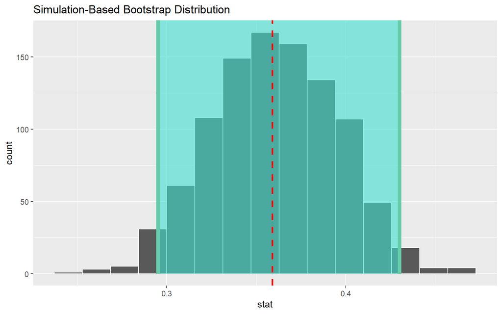

```r
dist_bootstrap |>
  visualise() +
  shade_confidence_interval(endpoints = ic_percentil) +
  geom_vline(xintercept = 0.359, color = "red", linetype = "dashed", linewidth = 1)
```

La línea roja punteada marca el valor real del parámetro ($p = 0.359$). Si cae dentro de la zona sombreada, nuestro IC capturó el verdadero valor — que es lo que esperamos que ocurra el **95% de las veces** si repitiéramos este procedimiento.

### Pregunta 5: ¿Qué pasa con más datos?

Repita el ejercicio pero ahora con una muestra de **1.000 personas** en vez de 200. Compare el ancho del nuevo IC con el anterior. ¿Qué concluye?

**Pauta**

**Código**

```r
muestra_grande <- poblacion |> slice_sample(n = 1000)

ic_grande <- muestra_grande |>
  specify(response = indigena, success = "si") |>
  generate(reps = 1000, type = "bootstrap") |>
  calculate(stat = "prop") |>
  get_confidence_interval(level = 0.95, type = "percentile")

ic_grande
```

| lower_ci | upper_ci |
| --- | --- |
| 0.342975 | 0.402025 |

**Código**

```r
# Comparación de anchos
ancho_200  <- ic_percentil$upper_ci - ic_percentil$lower_ci
ancho_1000 <- ic_grande$upper_ci - ic_grande$lower_ci

tibble(
  muestra = c("n = 200", "n = 1.000"),
  ancho_ic = round(c(ancho_200, ancho_1000), 4)
)
```

| muestra | ancho_ic |
| --- | --- |
| n = 200 | 0.135 |
| n = 1.000 | 0.059 |

El IC con $n = 1.000$ es **considerablemente más angosto** que el de $n = 200$. Con más datos, nuestro estimador tiene menos variabilidad y por lo tanto podemos estimar el parámetro con mayor **precisión**. Esta es la intuición detrás de por qué muestras más grandes son más informativas.

# Resumen

| Paso | Función `infer` | ¿Qué hace? |
| --- | --- | --- |
| 1 | `specify(response, success)` | Define la variable y el valor de éxito |
| 2 | `generate(reps, type = "bootstrap")` | Genera remuestras con reemplazo |
| 3 | `calculate(stat = "prop")` | Calcula la proporción en cada remuestra |
| 4 | `get_confidence_interval(level)` | Construye el IC (percentiles o SE) |
| — | `visualise() + shade_confidence_interval()` | Grafica la distribución y el IC |